# Regression Model for Bike Sharing Using R - Take 3

David Lowe

June 1, 2018

Template Credit: Adapted from a template made available by Dr. Jason Brownlee of Machine Learning Mastery (http://machinelearningmastery.com/)

Dataset Used: Bike Sharing Dataset

Dataset ML Model: Regression with numerical attributes

Dataset Reference: https://archive.ics.uci.edu/ml/datasets/Bike+Sharing+Dataset

For performance benchmarks, please consult: https://www.kaggle.com/contactprad/bike-share-daily-data

INTRODUCTION: Using the data generated by a bike sharing system, this project attempts to predict the daily demand for bike sharing. For this iteration of the project, we attempt to use the data available for discovering a suitable machine learning algorithm that future predictions can use. We have kept the data transformation activities to a minimum and drop the several attributes that do not make sense to keep or simply will not help in training the model.

For the Take No.3 of the project, we will leverage the hourly data, instead of the daily data from Take No.1. We will examine the algorithm performance and see how the hourly dataset performs against the daily data for modeling algorithms.

Random Forest also processed the validation dataset with an RMSE value of 64 (vs. 1177 using the daily data) and an R-square value of 0.8778 (vs. 0.6329 using the daily data), which was better than the average training result. For this project, the Random Forest ensemble algorithm yielded top-notch training and validation results, which warrant the additional processing required by the algorithm.

Furthermore, the use of hourly data (vs. daily data) generally yielded significantly higher R-square values for all algorithms. It would be a recommended approach to leverage the predictive models by using the hourly data whenever possible.

The purpose of this project is to analyze predictions using various machine learning algorithms and to document the steps using a template. Working through machine learning problems from end-to-end requires a structured modeling approach. Working problems through a project template can also encourage us to think about the problem more critically, to challenge our assumptions, and to get proficient at all parts of a modeling project.

The project aims to touch on the following areas:

1. Document a predictive modeling problem end-to-end.
2. Explore data cleaning and transformation options
3. Explore non-ensemble and ensemble algorithms for baseline model performance
4. Explore algorithm tuning techniques for improving model performance

Any predictive modeling machine learning project genrally can be broken down into about six major tasks:

1. Prepare Problem
2. Summarize Data
3. Prepare Data
4. Model and Evaluate Algorithms
5. Improve Accuracy or Results
6. Finalize Model and Present Results

## 1. Prepare Problem

### 1.a) Load libraries

```r
library(caret)
```

```r
library(corrplot)
```

### 1.b) Load dataset

```r
startTimeScript <- proc.time()
entireDataset <- read.csv("bike-sharing-hour.csv", header= TRUE)

# We are making some preliminary assumptions to drop certain attributes right from the beginning.
# Assumption #1: Drop the "instant" column since it is just an unique row identifier.
# Assumption #2: Drop the "detday" column since it is just an unique date field.
# Assumption #3: Drop the "yr" column since it was just an date representation and a one-time occurance.
# Assumption #4: Drop the "casual" and "registered" columns since they are just derived number from the target variable and directly correlate with it.
entireDataset$instant <- NULL
entireDataset$dteday <- NULL
entireDataset$yr <- NULL
entireDataset$casual <- NULL
entireDataset$registered <- NULL

# Use variable totCol to hold the number of columns in the dataframe
totCol <- ncol(entireDataset)

# Rename the class/target column to a standard label
colnames(entireDataset)[ncol(entireDataset)] <- "targetVar"
```

## 2. Summarize Data

To gain a better understanding of the data that we have on-hand, we will leverage a number of descriptive statistics and data visualization techniques. The plan is to use the results to consider new questions, review assumptions, and validate hypotheses that we can investigate later with specialized models.

### 2.a) Descriptive statistics

#### 2.a.i) Peek at the data itself.

```r
head(entireDataset)
```

```
##   season mnth hr holiday weekday workingday weathersit temp  atemp  hum
## 1      1    1  0       0       6          0          1 0.24 0.2879 0.81
## 2      1    1  1       0       6          0          1 0.22 0.2727 0.80
## 3      1    1  2       0       6          0          1 0.22 0.2727 0.80
## 4      1    1  3       0       6          0          1 0.24 0.2879 0.75
## 5      1    1  4       0       6          0          1 0.24 0.2879 0.75
## 6      1    1  5       0       6          0          2 0.24 0.2576 0.75
##   windspeed targetVar
## 1    0.0000        16
## 2    0.0000        40
## 3    0.0000        32
## 4    0.0000        13
## 5    0.0000         1
## 6    0.0896         1
```

#### 2.a.ii) Dimensions of the dataset.

```r
dim(entireDataset)
```

```
## [1] 17379    12
```

#### 2.a.iii) Types of the attributes.

```r
sapply(entireDataset, class)
```

```
##     season       mnth         hr    holiday    weekday workingday
##  "integer"  "integer"  "integer"  "integer"  "integer"  "integer"
## weathersit       temp      atemp        hum  windspeed  targetVar
##  "integer"  "numeric"  "numeric"  "numeric"  "numeric"  "integer"
```

#### 2.a.iv) Statistical summary of all attributes.

```r
summary(entireDataset)
```

```
##      season           mnth              hr           holiday
##  Min.   :1.000   Min.   : 1.000   Min.   : 0.00   Min.   :0.00000
##  1st Qu.:2.000   1st Qu.: 4.000   1st Qu.: 6.00   1st Qu.:0.00000
##  Median :3.000   Median : 7.000   Median :12.00   Median :0.00000
##  Mean   :2.502   Mean   : 6.538   Mean   :11.55   Mean   :0.02877
##  3rd Qu.:3.000   3rd Qu.:10.000   3rd Qu.:18.00   3rd Qu.:0.00000
##  Max.   :4.000   Max.   :12.000   Max.   :23.00   Max.   :1.00000
##     weekday        workingday       weathersit         temp
##  Min.   :0.000   Min.   :0.0000   Min.   :1.000   Min.   :0.020
##  1st Qu.:1.000   1st Qu.:0.0000   1st Qu.:1.000   1st Qu.:0.340
##  Median :3.000   Median :1.0000   Median :1.000   Median :0.500
##  Mean   :3.004   Mean   :0.6827   Mean   :1.425   Mean   :0.497
##  3rd Qu.:5.000   3rd Qu.:1.0000   3rd Qu.:2.000   3rd Qu.:0.660
##  Max.   :6.000   Max.   :1.0000   Max.   :4.000   Max.   :1.000
##      atemp             hum           windspeed        targetVar
##  Min.   :0.0000   Min.   :0.0000   Min.   :0.0000   Min.   :  1.0
##  1st Qu.:0.3333   1st Qu.:0.4800   1st Qu.:0.1045   1st Qu.: 40.0
##  Median :0.4848   Median :0.6300   Median :0.1940   Median :142.0
##  Mean   :0.4758   Mean   :0.6272   Mean   :0.1901   Mean   :189.5
##  3rd Qu.:0.6212   3rd Qu.:0.7800   3rd Qu.:0.2537   3rd Qu.:281.0
##  Max.   :1.0000   Max.   :1.0000   Max.   :0.8507   Max.   :977.0
```

#### 2.a.v) Count missing values.

```r
sapply(entireDataset, function(x) sum(is.na(x)))
```

```
##     season       mnth         hr    holiday    weekday workingday
##          0          0          0          0          0          0
## weathersit       temp      atemp        hum  windspeed  targetVar
##          0          0          0          0          0          0
```

### 2.b) Data visualizations

#### 2.b.i) Univariate plots to better understand each attribute.

```r
# Set up a variable for the total number of attribute columns (totAttr)
totAttr <- totCol-1
# Set up the number of row and columns for visualization display. dispRow * dispCol should be >= totAttr
dispCol <- 7
if (totAttr%%dispCol == 0) {
dispRow <- totAttr%/%dispCol
} else {
dispRow <- (totAttr%/%dispCol) + 1
}
```

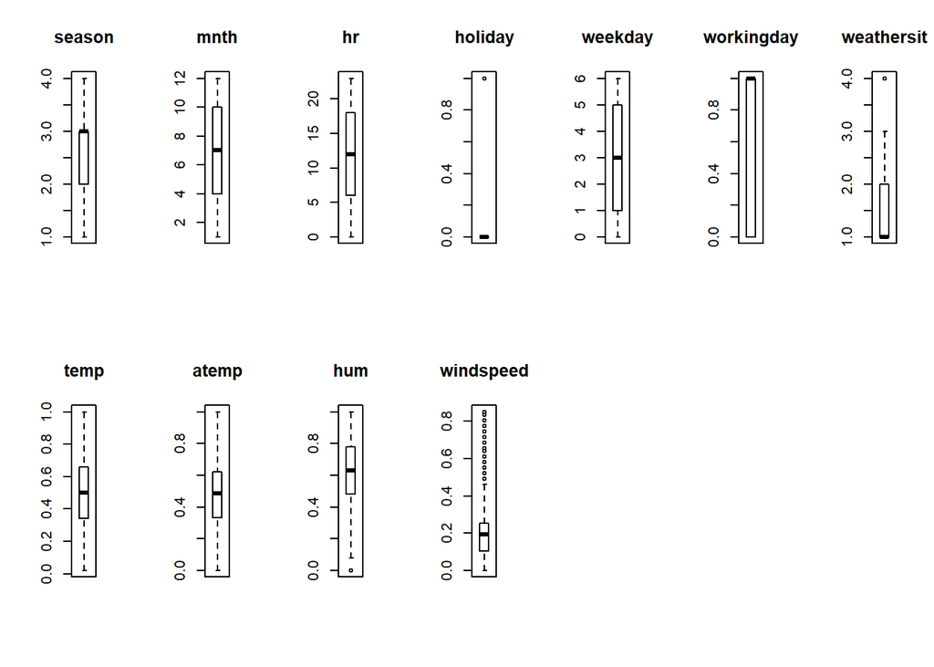

```r
# Boxplots for each attribute
par(mfrow=c(dispRow,dispCol))
for(i in 1:totAttr) {
    boxplot(entireDataset[,i], main=names(entireDataset)[i])
}
```

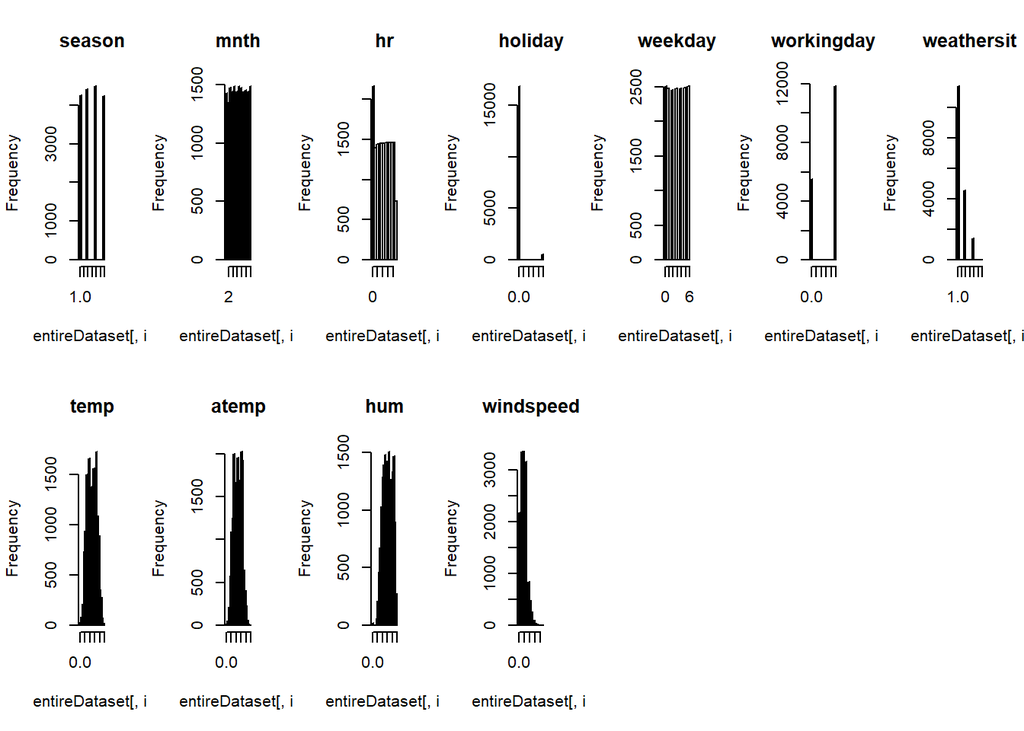

```r
# Histograms each attribute
par(mfrow=c(dispRow,dispCol))
for(i in 1:totAttr) {
    hist(entireDataset[,i], main=names(entireDataset)[i])
}
```

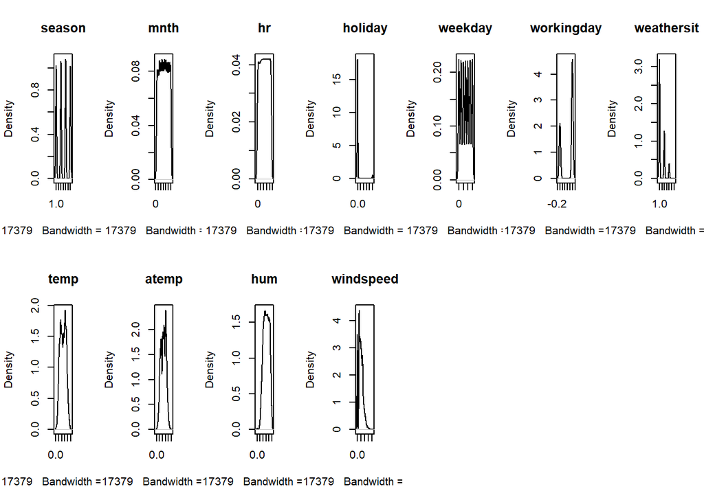

```r
# Density plot for each attribute
par(mfrow=c(dispRow,dispCol))
for(i in 1:totAttr) {
    plot(density(entireDataset[,i]), main=names(entireDataset)[i])
}
```

#### 2.b.ii) Multivariate plots to better understand the relationships between attributes

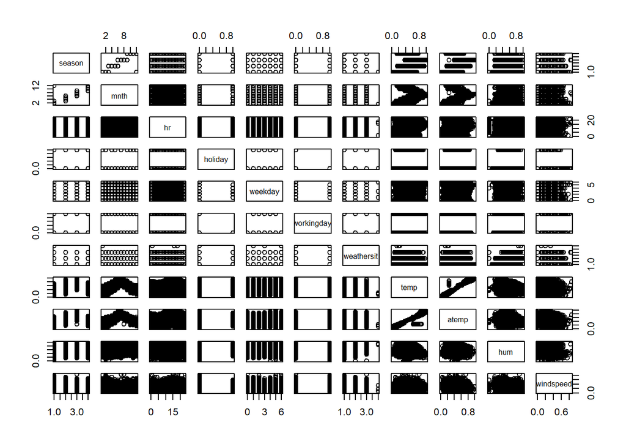

```r
# Scatterplot matrix colored by class
pairs(entireDataset[,1:totAttr])
```

```r
#pairs(targetVar~., data=entireDataset, col=training$targetVar)
```

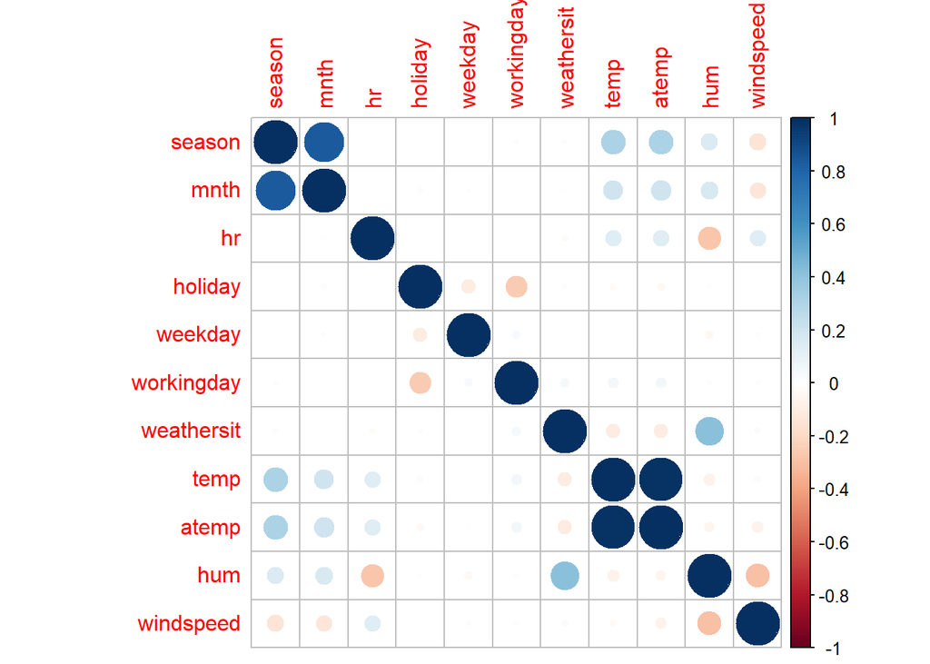

```r
# Correlation plot
correlations <- cor(entireDataset[,1:totAttr])
corrplot(correlations, method="circle")
```

## 3. Prepare Data

Some dataset may require additional preparation activities that will best exposes the structure of the problem and the relationships between the input attributes and the output variable. Some data-prep tasks might include:

- Cleaning data by removing duplicates, marking missing values and even imputing missing values.
- Feature selection where redundant features may be removed.
- Data transforms where attributes are scaled or redistributed in order to best expose the structure of the problem later to learning algorithms.

### 3.a) Data Cleaning

```r
# Not applicable for this iteration of the project.

# Mark missing values
#invalid <- 0
#entireDataset$some_col[entireDataset$some_col==invalid] <- NA

# Impute missing values
#entireDataset$some_col <- with(entireDataset, impute(some_col, mean))
```

### 3.b) Feature Selection

```r
# Not applicable for this iteration of the project.
```

### 3.c) Data Transforms

```r
# Not applicable for this iteration of the project.
```

### 3.d) Split-out training and validation datasets

We create a training dataset (variable name “training”) and a validation dataset (variable name “validation”).

```r
seedNum <- 888
set.seed(seedNum)

# Create a list of 70% of the rows in the original dataset we can use for training
training_index <- createDataPartition(entireDataset$targetVar, p=0.70, list=FALSE)

# Use 70% of data to training and testing the models
training <- entireDataset[training_index,]

# Select the remaining 30% of the data for validation
validation <- entireDataset[-training_index,]
```

```r
proc.time()-startTimeScript
```

```
##    user  system elapsed
##    6.09   43.69   51.01
```

## 4. Model and Evaluate Algorithms

After the data-prep, we next work on finding a workable model by evaluating a subset of machine learning algorithms that are good at exploiting the structure of the dataset. The typical evaluation tasks include:

- Defining test options such as cross validation and the evaluation metric to use.
- Spot checking a suite of linear and nonlinear machine learning algorithms.
- Comparing the estimated accuracy of algorithms.

For this project, we will evaluate one linear, three non-linear and three ensemble algorithms:

Linear Algorithm: Linear Regression

Non-Linear Algorithms: Decision Trees (CART), k-Nearest Neighbors, and Support Vector Machine

Ensemble Algorithms: Bagged CART, Random Forest, and Stochastic Gradient Boosting

The random number seed is reset before each run to ensure that the evaluation of each algorithm is performed using the same data splits. It ensures the results are directly comparable.

### 4.a) Set test options and evaluation metric

```r
# Run algorithms using 10-fold cross validation
control <- trainControl(method="repeatedcv", number=10, repeats=3)
metricTarget <- "RMSE"
```

### 4.b) Generate models using linear algorithms

```r
# Linear Regression (Regression)
startTimeModule <- proc.time()
set.seed(seedNum)
fit.lm <- train(targetVar~., data=training, method="lm", metric=metricTarget, trControl=control)
proc.time()-startTimeModule
```

```
##    user  system elapsed
##    1.39    0.01    1.44
```

### 4.c) Generate models using nonlinear algorithms

```r
# Decision Tree - CART (Regression/Classification)
startTimeModule <- proc.time()
set.seed(seedNum)
fit.cart <- train(targetVar~., data=training, method="rpart", metric=metricTarget, trControl=control)
proc.time()-startTimeModule
```

```
##    user  system elapsed
##    2.49    0.00    2.55
```

```r
# k-Nearest Neighbors (Regression/Classification)
startTimeModule <- proc.time()
set.seed(seedNum)
fit.knn <- train(targetVar~., data=training, method="knn", metric=metricTarget, trControl=control)
proc.time()-startTimeModule
```

```
##    user  system elapsed
##   19.72    0.04   22.90
```

```r
# Support Vector Machine (Regression/Classification)
startTimeModule <- proc.time()
set.seed(seedNum)
fit.svm <- train(targetVar~., data=training, method="svmRadial", metric=metricTarget, trControl=control)
proc.time()-startTimeModule
```

```
##    user  system elapsed
## 1445.87   17.45 1467.04
```

### 4.d) Generate models using ensemble algorithms

In this section, we will explore the use and tuning of ensemble algorithms to see whether we can improve the results.

```r
# Bagged CART (Regression/Classification)
startTimeModule <- proc.time()
set.seed(seedNum)
fit.bagcart <- train(targetVar~., data=training, method="treebag", metric=metricTarget, trControl=control)
proc.time()-startTimeModule
```

```
##    user  system elapsed
##   26.06    0.01   26.18
```

```r
# Random Forest (Regression/Classification)
startTimeModule <- proc.time()
set.seed(seedNum)
fit.rf <- train(targetVar~., data=training, method="rf", metric=metricTarget, trControl=control)
proc.time()-startTimeModule
```

```
##    user  system elapsed
## 8040.40   14.86 8069.70
```

```r
# Stochastic Gradient Boosting (Regression/Classification)
startTimeModule <- proc.time()
set.seed(seedNum)
fit.gbm <- train(targetVar~., data=training, method="gbm", metric=metricTarget, trControl=control, verbose=F)
proc.time()-startTimeModule
```

```
##    user  system elapsed
##   48.76    0.18   49.05
```

### 4.e) Compare baseline algorithms

```r
results <- resamples(list(LR=fit.lm, CART=fit.cart, kNN=fit.knn, SVM=fit.svm, BagCART=fit.bagcart, RF=fit.rf, GBM=fit.gbm))
summary(results)
```

```
##
## Call:
## summary.resamples(object = results)
##
## Models: LR, CART, kNN, SVM, BagCART, RF, GBM
## Number of resamples: 30
##
## MAE
##              Min.   1st Qu.    Median      Mean   3rd Qu.      Max. NA's
## LR      103.62468 107.26160 108.42518 108.71153 110.58534 114.04707    0
## CART     90.41731  92.98358  94.38046  94.87728  96.37390 101.94611    0
## kNN      48.48197  50.31016  51.27436  51.21983  52.15217  53.48085    0
## SVM      73.03155  74.54164  76.26453  76.12012  77.68516  79.55668    0
## BagCART  70.32826  71.54576  72.30398  72.25768  72.77404  74.40003    0
## RF       41.90975  43.59667  43.99961  44.09544  44.75480  45.97080    0
## GBM      57.61199  58.86715  59.65737  60.08537  61.30265  64.22745    0
##
## RMSE
##              Min.   1st Qu.    Median      Mean   3rd Qu.      Max. NA's
## LR      140.87140 145.34202 148.50672 148.14273 150.83073 159.17609    0
## CART    129.22243 133.06899 134.72993 135.42176 136.85415 145.61943    0
## kNN      72.02935  75.55288  77.60916  77.25083  78.88447  81.20100    0
## SVM     115.01906 121.09828 124.08112 124.01924 125.69480 137.06834    0
## BagCART  97.90046 100.10700 102.18980 101.84299 103.45753 104.58725    0
## RF       62.41682  65.71363  67.16651  66.94695  68.24420  71.28928    0
## GBM      82.39636  84.55843  85.81903  86.38047  87.99074  91.75035    0
##
## Rsquared
##              Min.   1st Qu.    Median      Mean   3rd Qu.      Max. NA's
## LR      0.2946328 0.3206645 0.3305448 0.3321676 0.3436184 0.3918700    0
## CART    0.3750329 0.4203340 0.4509662 0.4417811 0.4593603 0.4821548    0
## kNN     0.8001993 0.8152501 0.8178987 0.8192468 0.8257038 0.8379771    0
## SVM     0.5117537 0.5511845 0.5593079 0.5624118 0.5754446 0.6207803    0
## BagCART 0.6544234 0.6705393 0.6852105 0.6846729 0.6940453 0.7158289    0
## RF      0.8410909 0.8574101 0.8662837 0.8645751 0.8704507 0.8851563    0
## GBM     0.7463895 0.7726156 0.7777536 0.7772604 0.7862698 0.8014267    0
```

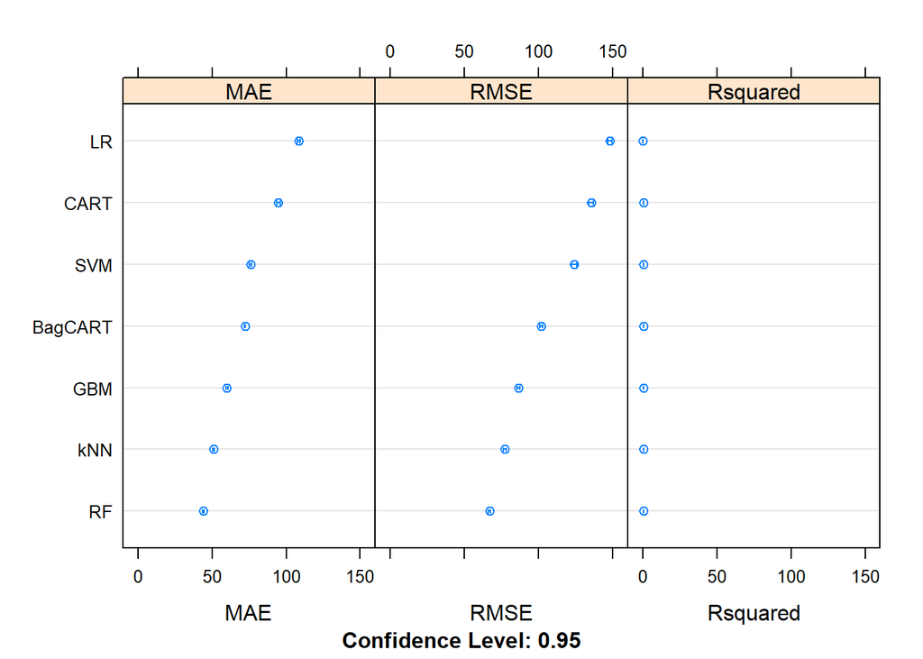

```r
dotplot(results)
```

## 5. Improve Accuracy or Results

After we achieve a short list of machine learning algorithms with good level of accuracy, we can leverage ways to improve the accuracy of the models.

Using the three best-perfoming algorithms from the previous section, we will Search for a combination of parameters for each algorithm that yields the best results.

### 5.a) Algorithm Tuning

Finally, we will tune the best-performing algorithms from each group further and see whether we can get more accuracy out of them.

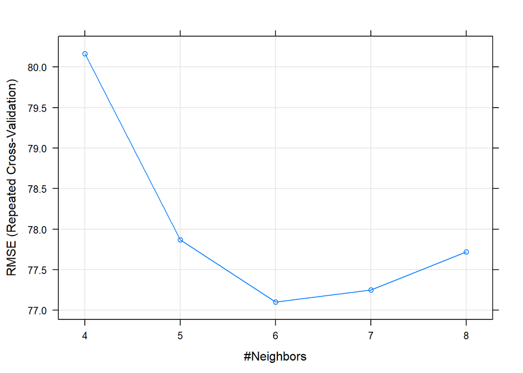

```r
# Tuning algorithm #1 - k-Nearest Neighbors
startTimeModule <- proc.time()
set.seed(seedNum)
grid <- expand.grid(k = c(4:8))
fit.final1 <- train(targetVar~., data=training, method="knn", metric=metricTarget, tuneGrid=grid, trControl=control)
plot(fit.final1)
```

```r
print(fit.final1)
```

```
## k-Nearest Neighbors
##
## 12167 samples
##    11 predictor
##
## No pre-processing
## Resampling: Cross-Validated (10 fold, repeated 3 times)
## Summary of sample sizes: 10951, 10951, 10952, 10951, 10951, 10949, ...
## Resampling results across tuning parameters:
##
##   k  RMSE      Rsquared   MAE
##   4  80.16540  0.8049928  52.66802
##   5  77.86706  0.8159116  51.40654
##   6  77.10071  0.8197600  51.01393
##   7  77.25083  0.8192468  51.21983
##   8  77.71924  0.8171716  51.75530
##
## RMSE was used to select the optimal model using the smallest value.
## The final value used for the model was k = 6.
```

```r
proc.time()-startTimeModule
```

```
##    user  system elapsed
##   27.57    0.05   27.69
```

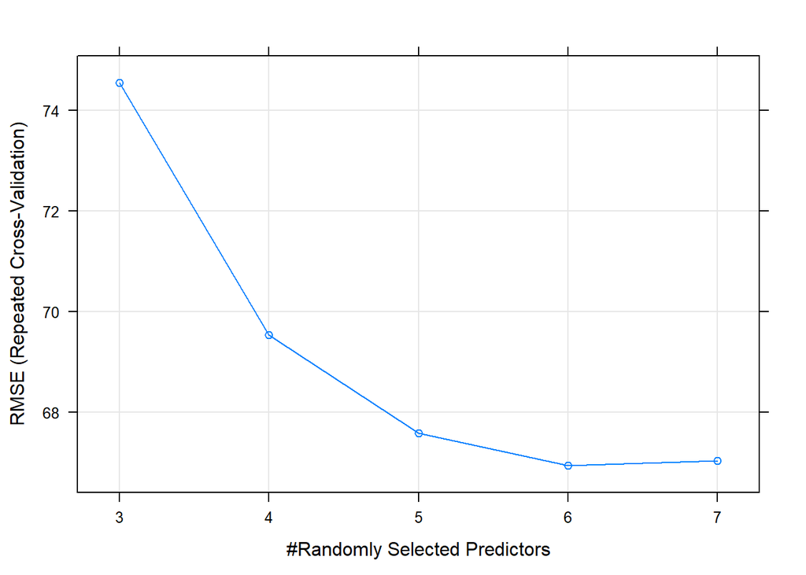

```r
# Tuning algorithm #2 - Random Forest
startTimeModule <- proc.time()
set.seed(seedNum)
grid <- expand.grid(mtry = c(3:7))
fit.final2 <- train(targetVar~., data=training, method="rf", metric=metricTarget, tuneGrid=grid, trControl=control)
plot(fit.final2)
```

```r
print(fit.final2)
```

```
## Random Forest
##
## 12167 samples
##    11 predictor
##
## No pre-processing
## Resampling: Cross-Validated (10 fold, repeated 3 times)
## Summary of sample sizes: 10951, 10951, 10952, 10951, 10951, 10949, ...
## Resampling results across tuning parameters:
##
##   mtry  RMSE      Rsquared   MAE
##   3     74.54656  0.8394962  49.17568
##   4     69.53542  0.8571195  45.81228
##   5     67.58280  0.8630636  44.50936
##   6     66.93575  0.8646264  44.09113
##   7     67.03044  0.8637327  44.14396
##
## RMSE was used to select the optimal model using the smallest value.
## The final value used for the model was mtry = 6.
```

```r
proc.time()-startTimeModule
```

```
##     user   system  elapsed
## 12108.75    23.34 12144.26
```

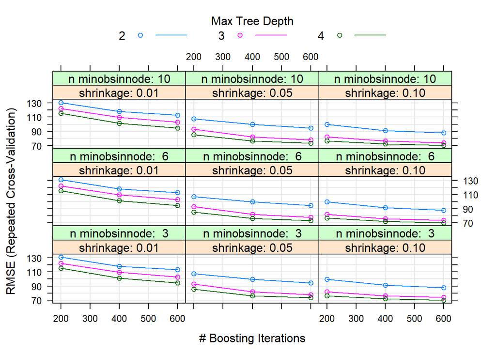

```r
# Tuning algorithm #3 - Stochastic Gradient Boosting
startTimeModule <- proc.time()
set.seed(seedNum)
grid <- expand.grid(.n.trees=c(200, 400, 600), .shrinkage=c(0.01, 0.05, 0.1), .interaction.depth=c(2, 3, 4), .n.minobsinnode=c(3, 6, 10))
fit.final3 <- train(targetVar~., data=training, method="gbm", metric=metricTarget, tuneGrid=grid, trControl=control, verbose=F)
plot(fit.final3)
```

```r
print(fit.final3)
```

```
## Stochastic Gradient Boosting
##
## 12167 samples
##    11 predictor
##
## No pre-processing
## Resampling: Cross-Validated (10 fold, repeated 3 times)
## Summary of sample sizes: 10951, 10951, 10952, 10951, 10951, 10949, ...
## Resampling results across tuning parameters:
##
##   shrinkage  interaction.depth  n.minobsinnode  n.trees  RMSE
##   0.01       2                   3              200      130.56287
##   0.01       2                   3              400      117.77251
##   0.01       2                   3              600      112.98839
##   0.01       2                   6              200      130.63506
##   0.01       2                   6              400      117.75328
##   0.01       2                   6              600      112.99449
##   0.01       2                  10              200      130.69278
##   0.01       2                  10              400      117.81427
##   0.01       2                  10              600      113.04844
##   0.01       3                   3              200      122.24337
##   0.01       3                   3              400      109.63743
##   0.01       3                   3              600      102.69596
##   0.01       3                   6              200      122.28812
##   0.01       3                   6              400      109.71003
##   0.01       3                   6              600      102.62499
##   0.01       3                  10              200      122.33100
##   0.01       3                  10              400      109.75575
##   0.01       3                  10              600      102.72378
##   0.01       4                   3              200      115.25471
##   0.01       4                   3              400      101.40414
##   0.01       4                   3              600       94.66781
##   0.01       4                   6              200      115.29448
##   0.01       4                   6              400      101.48414
##   0.01       4                   6              600       94.66165
##   0.01       4                  10              200      115.24196
##   0.01       4                  10              400      101.34490
##   0.01       4                  10              600       94.55110
##   0.05       2                   3              200      107.30562
##   0.05       2                   3              400       99.92480
```

[output cut: 123 more lines]

```
##   0.8241123  53.50438
##   0.8339239  51.85455
##   0.8234016  53.44293
##   0.8427348  50.28979
##   0.8507645  48.79570
##   0.8226391  53.45692
##   0.8420767  50.31413
##   0.8497477  48.92241
##   0.8230824  53.37229
##   0.8419218  50.30002
##   0.8498518  48.94484
##
## RMSE was used to select the optimal model using the smallest value.
## The final values used for the model were n.trees = 600,
##  interaction.depth = 4, shrinkage = 0.1 and n.minobsinnode = 3.
```

```r
proc.time()-startTimeModule
```

```
##    user  system elapsed
## 2134.08    0.32 2136.46
```

### 5.d) Compare Algorithms After Tuning

```r
results <- resamples(list(KNN=fit.final1, RF=fit.final2, GBM=fit.final3))
summary(results)
```

```
##
## Call:
## summary.resamples(object = results)
##
## Models: KNN, RF, GBM
## Number of resamples: 30
##
## MAE
##         Min.  1st Qu.   Median     Mean  3rd Qu.     Max. NA's
## KNN 48.29630 50.14542 51.34420 51.01393 51.81073 53.27139    0
## RF  41.90167 43.58511 43.99241 44.09113 44.66957 46.07658    0
## GBM 46.34491 48.13431 48.65355 48.79570 49.68326 50.92484    0
##
## RMSE
##         Min.  1st Qu.   Median     Mean  3rd Qu.     Max. NA's
## KNN 71.51133 75.63066 77.41414 77.10071 78.95226 80.95354    0
## RF  62.34668 65.91133 67.29670 66.93575 68.40408 71.30153    0
## GBM 65.20475 68.56275 70.49878 70.15541 71.74420 73.03483    0
##
## Rsquared
##          Min.   1st Qu.    Median      Mean   3rd Qu.      Max. NA's
## KNN 0.8012240 0.8153591 0.8185718 0.8197600 0.8262796 0.8415982    0
## RF  0.8410441 0.8574222 0.8667148 0.8646264 0.8699173 0.8854415    0
## GBM 0.8350244 0.8422470 0.8502011 0.8507645 0.8591275 0.8721005    0
```

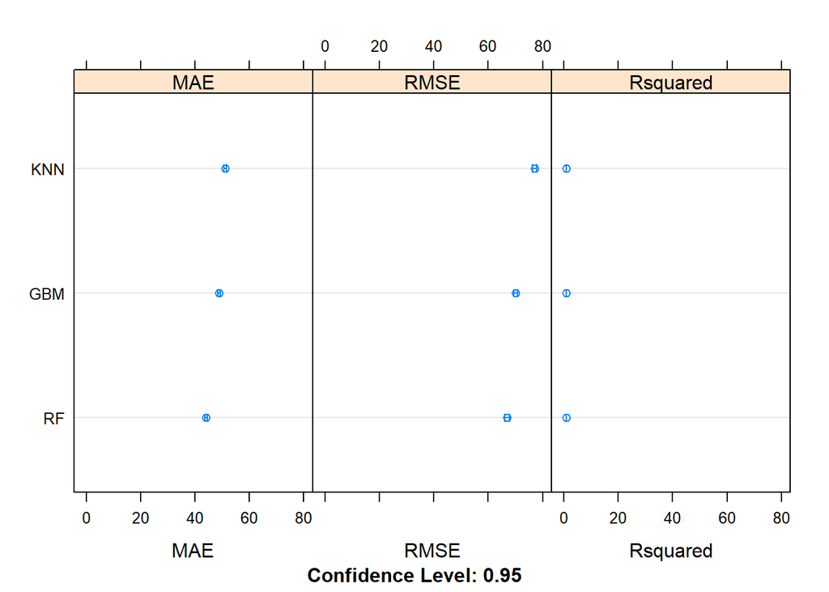

```r
dotplot(results)
```

## 6. Finalize Model and Present Results

Once we have narrow down to a model that we believe can make accurate predictions on unseen data, we are ready to finalize it. Finalizing a model may involve sub-tasks such as:

- Using an optimal model tuned to make predictions on unseen data.
- Creating a standalone model using the tuned parameters
- Saving an optimal model to file for later use.

### 6.a) Predictions on validation dataset

```r
predictions <- predict(fit.final2, newdata=validation)
valY <- validation[,totCol]
print(RMSE(predictions, valY))
```

```
## [1] 63.71978
```

```r
print(R2(predictions, valY))
```

```
## [1] 0.8778262
```

### 6.b) Create standalone model on entire training dataset

```r
library(randomForest)
startTimeModule <- proc.time()
set.seed(seedNum)
finalModel <- randomForest(targetVar~., entireDataset, mtry = 6)
print(finalModel)
```

```
##
## Call:
##  randomForest(formula = targetVar ~ ., data = entireDataset, mtry = 6)
##                Type of random forest: regression
##                      Number of trees: 500
## No. of variables tried at each split: 6
##
##           Mean of squared residuals: 4002.057
##                     % Var explained: 87.84
```

```r
proc.time()-startTimeModule
```

```
##    user  system elapsed
##  212.30    0.21  212.65
```

### 6.c) Save model for later use

```r
#saveRDS(finalModel, "./finalModel_Regression.rds")
```

```r
proc.time()-startTimeScript
```

```
##     user   system  elapsed
## 24077.95   100.47 24215.72
```